# Assignment 1

Li Yuanhao

2026-09-28

# Part 1 - Investigation on Singapore Resale Price of HDB Flats

```r
library(dplyr)
library(ggplot2)
library(tidyverse)
library(ggthemes)
library(scales)
library(lubridate)
library(ggrepel)
library(ggridges)
library(forcats)
library(stringr)
library(ggtext)
```

First, load the dataset of Resale Flats:

```r
Resale_Price_2017 <- read_csv("data/ResaleFlatPrices/Resale flat prices based on registration date from Jan-2017 onwards.csv")
```

## Understanding the dataset

Let’s have a quick check about the dataset:

```r
head(Resale_Price_2017)
```

```
## # A tibble: 6 × 11
##   month town  flat_type block street_name storey_range floor_area_sqm flat_model
##   <chr> <chr> <chr>     <chr> <chr>       <chr>                 <dbl> <chr>
## 1 2017… ANG … 2 ROOM    406   ANG MO KIO… 10 TO 12                 44 Improved
## 2 2017… ANG … 3 ROOM    108   ANG MO KIO… 01 TO 03                 67 New Gener…
## 3 2017… ANG … 3 ROOM    602   ANG MO KIO… 01 TO 03                 67 New Gener…
## 4 2017… ANG … 3 ROOM    465   ANG MO KIO… 04 TO 06                 68 New Gener…
## 5 2017… ANG … 3 ROOM    601   ANG MO KIO… 01 TO 03                 67 New Gener…
## 6 2017… ANG … 3 ROOM    150   ANG MO KIO… 01 TO 03                 68 New Gener…
## # ℹ 3 more variables: lease_commence_date <dbl>, remaining_lease <chr>,
## #   resale_price <dbl>
```

The news said, “…the total number of million-dollar HDB flats to 261 for the whole of 2021, more than three times the 82 such flats in 2020.”

So, exactly how many HDB flats were “million-dollar” flats in 2020?

To get the month as a double number:

```r
Resale_Price_2017 %>%
  mutate(month_dbl = as.numeric(str_remove(Resale_Price_2017$month, '-'))) %>%
  select(month, month_dbl, everything()) -> Resale_Price_2017
```

And then select the HDB flats sold in 2020 & 2021 & 2025 which are more than $1m:

```r
Resale_Price_2017 %>%
  filter(month_dbl >= 202001 &month_dbl <= 202012) %>%
  filter(resale_price >= 1000000) -> Resale_Price_2020
'1m_flat_2020' <- nrow(Resale_Price_2020)
```

```r
Resale_Price_2017 %>%
  filter(month_dbl >= 202101 &month_dbl <= 202112) %>%
  filter(resale_price >= 1000000) -> Resale_Price_2021
'1m_flat_2021' <- nrow(Resale_Price_2021)
```

```r
Resale_Price_2017 %>%
  filter(month_dbl >= 202501 &month_dbl <= 202512) %>%
  filter(resale_price >= 1000000) -> Resale_Price_2025
length(Resale_Price_2025$resale_price)
```

```
## [1] 1593
```

Based on the data above, the number of HDB flats sold above $1 million was 82 in 2020, 259 in 2021, and 1,593 in 2025. This indicates a significant increase in the number of high-priced HDB flats.

```r
Resale_Price_2017 %>%
  filter(month_dbl == 202512) %>%
  summarise(average_price = mean(resale_price)) %>%
  pull(average_price) -> mean_2025_Dec
Resale_Price_2017 %>%
  filter(month_dbl == 202511) %>%
  summarise(average_price = mean(resale_price)) %>%
  pull(average_price) -> mean_2025_Nov
growth_rate_1month <- (mean_2025_Dec - mean_2025_Nov) / mean_2025_Nov
cat("The growth rate of HDB resale transaction prices from Nov. to Dec. 2025 is:", round(growth_rate_1month * 100, 2), "%\n")
```

```
## The growth rate of HDB resale transaction prices from Nov. to Dec. 2025 is: 1.74 %
```

Next, let’s compare the resale prices of HDB flats between December 2025 and December 2024:

```r
Resale_Price_2017 %>%
  filter(month_dbl == 202412) %>%
  summarise(average_price = mean(resale_price)) %>%
  pull(average_price) -> mean_2024_Dec
growth_rate_1year <- (mean_2025_Dec - mean_2024_Dec) / mean_2024_Dec
cat("The growth rate of HDB resale transaction prices from Dec. 2024 to Dec. 2025 is:", round(growth_rate_1year * 100, 2), "%\n")
```

```
## The growth rate of HDB resale transaction prices from Dec. 2024 to Dec. 2025 is: 3.47 %
```

Then, how many flats are sold in Dec. 2025:

```r
Resale_Price_2017 %>%
  filter(month_dbl == 202512) %>%
  nrow()
```

```
## [1] 2024
```

The number of HDB transactions in December 2025 was 2,024.

## Visualize the dataset.

So, what is the monthly volume of HDB transactions in 2025?

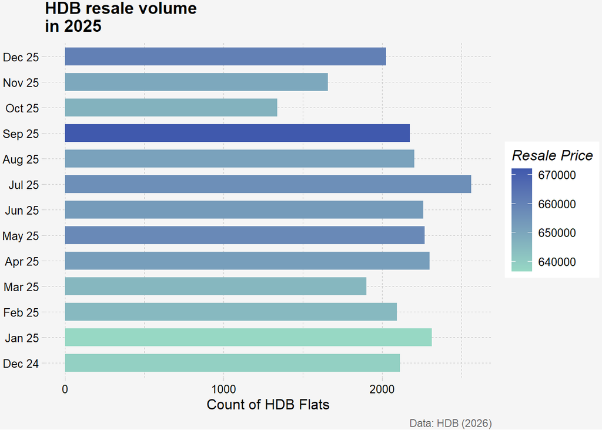

```r
Resale_Price_2017 %>%
  filter(month_dbl >= 202412 & month_dbl <= 202512) %>%
  group_by(month) %>%
  summarise(
    total_sales = n(),
    avg_price = mean(resale_price)
  ) %>%
  arrange(month) %>%
  mutate(
    m_num = as.numeric(substr(month, 6, 7)),
    y_num = substr(month, 3, 4),
    month_eng = paste(month.abb[m_num], y_num, sep = ' '),
    month_eng = factor(month_eng, levels = month_eng)
  ) %>%
  ggplot(mapping = aes(x = month_eng, y = total_sales, fill = avg_price)) +
  geom_col(width = 0.7) +
  scale_fill_gradient(low = "#97d8c4", high = "#4059ad") +
  theme_pander(
    bc = '#F5F5F5',
    pc = '#F5F5F5'
    ) +
  labs(
    title = paste("HDB resale volume",
                "in 2025", sep="\n"),
    caption = paste(
      "Data: HDB (2026)"
      ),
    x = NULL,
    y = 'Count of HDB Flats',
    fill = "Resale Price") +
  coord_flip() +
  theme(plot.title = element_text(hjust = 0, face = "bold", size = 14),
        plot.caption = element_text(hjust=1, colour="grey40"),
        plot.margin = margin(t = 1, r = 2, b = 1, l = 2, unit = "pt"))
```

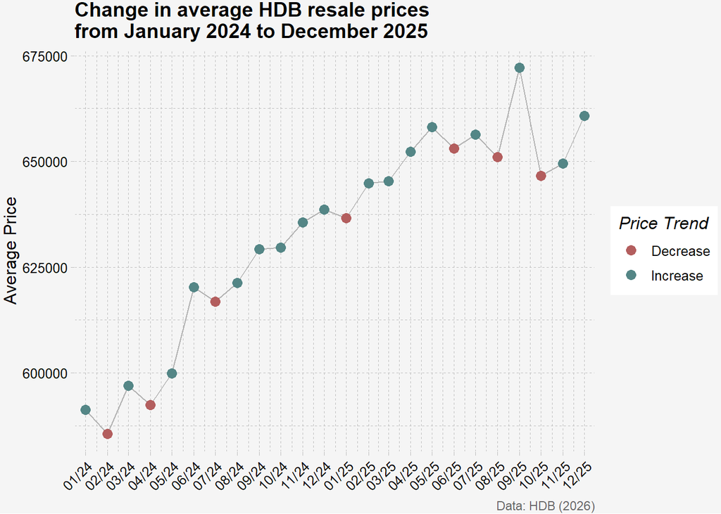

```r
Resale_Price_2017 %>%
  filter(month_dbl >= 202312 & month_dbl <= 202512) %>%
  group_by(month) %>%
  summarise(avg_price = mean(resale_price)) %>%
  mutate(month_date = ym(month)) %>%
  arrange(month_date) %>%
  mutate(growth_rate = (avg_price - lag(avg_price)) / lag(avg_price)) %>%
  mutate(growth_status = ifelse(growth_rate > 0, 'Increase', 'Decrease')) %>%
  filter(month >= '2024-01') %>%
  ggplot(mapping = aes(x = month_date, y = avg_price, group = 1)) +
  geom_line(colour = 'grey70', size = 0.5) +
  geom_point(mapping = aes(color = growth_status), size = 3) +
  scale_color_manual(
    values = c("Increase" = "#548686", "Decrease" = "#b35e5e")
  ) +
  theme_pander(
    bc = '#F5F5F5',
    pc = '#F5F5F5'
    ) +
  scale_x_date(
    date_labels = '%m/%y',
    date_breaks = '1 month',
    expand = expansion(add = 15)
    ) +
  labs(
    title = paste("Change in average HDB resale prices",
                "from January 2024 to December 2025", sep="\n"),
    caption = paste(
      "Data: HDB (2026)"
      ),
    x = NULL,
    y = 'Average Price',
    color = 'Price Trend') +
  theme(plot.title = element_text(hjust = 0, face = "bold", size = 14),
        plot.caption = element_text(hjust=1, colour="grey40"),
        plot.margin = margin(t = 1, r = 2, b = 1, l = 2, unit = "pt"),
        axis.text.x = element_text(angle = 45, hjust = 1)
        )
```

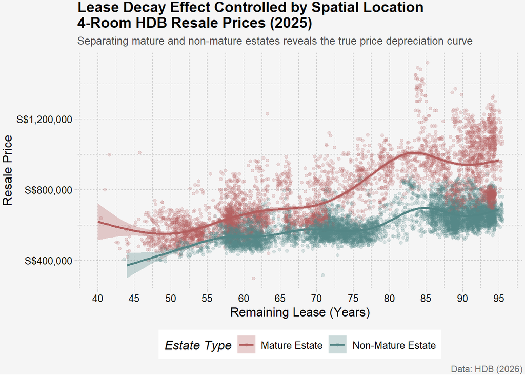

```r
mature_towns <- c("ANG MO KIO", "BEDOK", "BISHAN", "BUKIT MERAH",
                  "BUKIT TIMAH", "CENTRAL AREA", "CLEMENTI", "GEYLANG",
                  "KALLANG/WHAMPOA", "MARINE PARADE", "PASIR RIS",
                  "QUEENSTOWN", "SERANGOON", "TAMPINES", "TOA PAYOH")
Resale_Price_2017 %>%
  filter(month_dbl >= 202501 & month_dbl <= 202512) %>%
  filter(flat_type == '4 ROOM') %>%
  mutate(
    lease_years = as.numeric(substr(remaining_lease, 1, 2)),
    estate_type = ifelse(town %in% mature_towns, 'Mature Estate', 'Non-Mature Estate')
    ) %>%
  filter(!is.na(lease_years)) %>%
  ggplot(mapping = aes(x = lease_years, y = resale_price, colour = estate_type, fill = estate_type)) +
  geom_jitter(
    mapping = aes(color = estate_type),
    alpha = 0.2,
    size = 1.2,
    width = 0.5
    ) +
  geom_smooth(method = 'gam',
              formula = y ~ s(x, bs = 'cs'),
              size = 1, alpha = 0.3) +
  scale_color_manual(values = c('Mature Estate' = '#b35e5e', 'Non-Mature Estate' = '#548686')) +
  scale_fill_manual(values = c('Mature Estate' = '#b35e5e', 'Non-Mature Estate' = '#548686')) +
  scale_x_continuous(breaks = seq(40, 100, by = 5)) +
  scale_y_continuous(labels = label_dollar(prefix = 'S$')) +
  theme_pander(
    bc = '#F5F5F5',
    pc = '#F5F5F5'
  ) +
  labs(
    title = paste("Lease Decay Effect Controlled by Spatial Location",
                  "4-Room HDB Resale Prices (2025)", sep = "\n"),
    subtitle = "Separating mature and non-mature estates reveals the true price depreciation curve",
    caption = "Data: HDB (2026)",
    x = "Remaining Lease (Years)",
    y = 'Resale Price',
    color ='Estate Type',
    fill = 'Estate Type'
  ) +
  theme(
    plot.title = element_text(hjust = 0, face = 'bold', size = 14),
    plot.subtitle = element_text(hjust = 0, colour = 'grey30', size = 10),
    plot.caption = element_text(hjust = 1, colour = 'grey40'),
    legend.position = 'bottom',
    plot.margin = margin(t = 1, r = 2, b = 1, l = 2, unit = 'pt')
  )
```

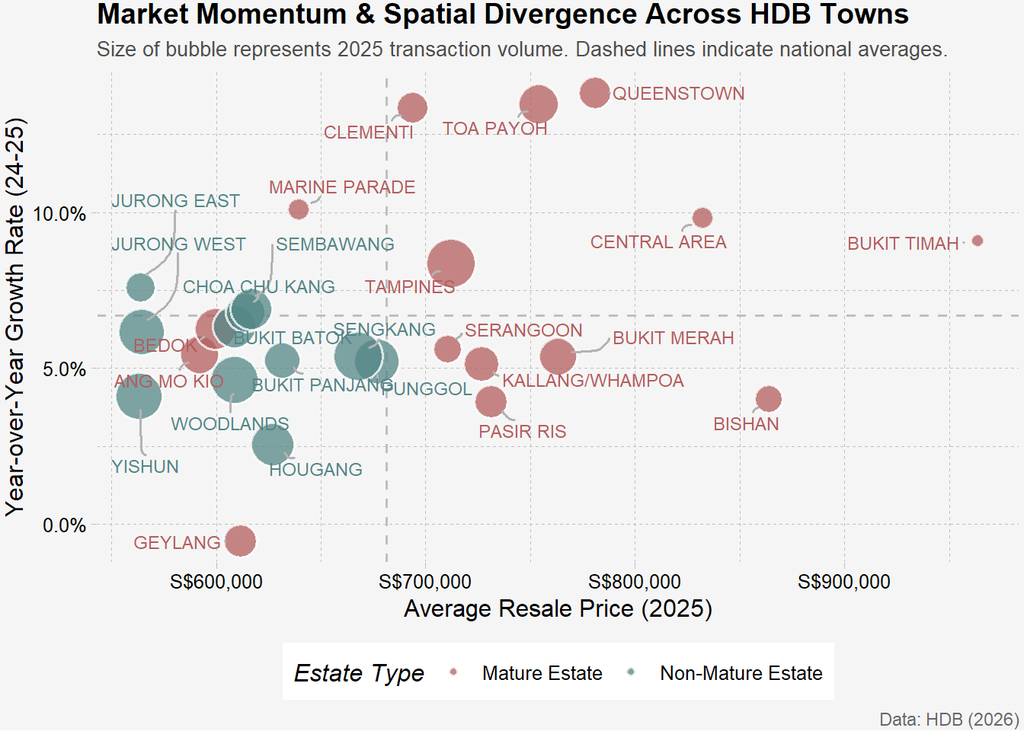

```r
Resale_Price_2017 %>%
  filter(month_dbl >= 202401 & month_dbl <= 202412) %>%
  group_by(town) %>%
  summarise(price_24 = mean(resale_price)) -> df_24

Resale_Price_2017 %>%
  filter(month_dbl >= 202501 & month_dbl <= 202512) %>%
  group_by(town) %>%
  summarise(
    price_25 = mean(resale_price),
    volume_25 = n()
    ) -> df_25

df_24_25 <- inner_join(df_24, df_25, by = 'town') %>%
  mutate(
    growth_rate = (price_25 - price_24) / price_24,
    estate_type = ifelse(town %in% mature_towns, 'Mature Estate', 'Non-Mature Estate')
  )

global_avg_price <- mean(df_24_25$price_25)
global_avg_growth <- mean(df_24_25$growth_rate)

ggplot(data = df_24_25, mapping = aes(x = price_25, y = growth_rate)) +
  geom_vline(
    xintercept = global_avg_price,
    linetype = 'dashed',
    color = 'grey75',
    size = 0.6
  ) +
  geom_hline(
    yintercept = global_avg_growth,
    linetype = 'dashed',
    color = 'grey75',
    size = 0.6
  ) +
  geom_point(
    aes(size = volume_25, fill = estate_type),
    colour = 'white',
    shape = 21,
    alpha = 0.75,
    stroke = 1
  ) +
  geom_text_repel(
    aes(label = town, color = estate_type),
    size = 3.2,
    point.padding = 0.4,
    box.padding = 0.5,
    #== Create Curved Segment (like NY Times?) ==
    segment.curvature = -0.2,
    segment.angle = 90,
    #============================================
    segment.color = 'grey70',
    segment.size = 0.6,
    min.segment.length = 0,
    max.overlaps = 50,
    show.legend = F
  ) +
  scale_fill_manual(values = c('Mature Estate' = '#b35e5e', 'Non-Mature Estate' = '#548686')) +
  scale_color_manual(values = c('Mature Estate' = '#b35e5e', 'Non-Mature Estate' = '#548686')) +
  scale_size_continuous(range = c(2.5, 11), guide = 'none') +
  scale_x_continuous(labels = label_dollar(prefix = 'S$')) +
  scale_y_continuous(labels = percent_format(accuracy = 0.1)) +
  theme_pander(
    bc = '#F5F5F5',
    pc = '#F5F5F5'
  ) +
  labs(
    title = paste("Market Momentum & Spatial Divergence Across HDB Towns"),
    subtitle = "Size of bubble represents 2025 transaction volume. Dashed lines indicate national averages.",
    caption = "Data: HDB (2026)",
    x = 'Average Resale Price (2025)',
    y = 'Year-over-Year Growth Rate (24-25)',
    fill = 'Estate Type'
  ) +
  theme(
    plot.title = element_text(hjust = 0, face = 'bold', size = 14),
    plot.subtitle = element_text(hjust = 0, colour = 'grey30', size = 10),
    plot.caption = element_text(hjust = 1, colour = 'grey40'),
    legend.position = 'bottom',
    plot.margin = margin(t = 1, r = 2, b = 1, l = 2, unit = 'pt')
  )
```

# Try to reproduce the chart.

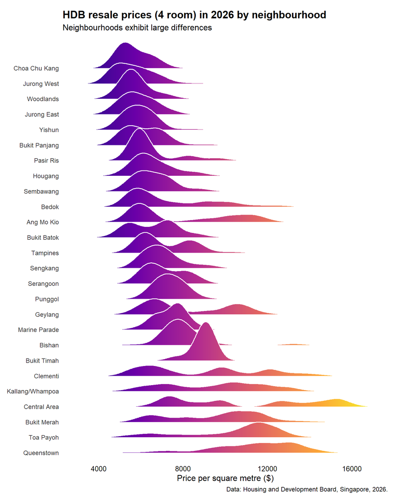

```r
df_ridges <- Resale_Price_2017 %>%
  filter(month_dbl >= 202601 & month_dbl <= 202612) %>%
  filter(flat_type == '4 ROOM') %>%
  mutate(
    price_per_sqm = resale_price / floor_area_sqm,
    town_label = str_to_title(town),
    town_label = str_replace(town_label, 'Kallang/whampoa', 'Kallang/Whampoa'),
    town_label = fct_reorder(town_label, price_per_sqm, median) %>% fct_rev()
  )

ggplot(data = df_ridges, aes(x = price_per_sqm, y = town_label, fill = after_stat(x))) +
  geom_density_ridges_gradient(
    scale = 2.5,
    rel_min_height = 0.01,
    colour = 'white',
    linewidth = 0.6
  ) +
  scale_fill_viridis_c(option = 'plasma') +
  scale_x_continuous(
    breaks = c(4000, 8000, 12000, 16000),
    limits = c(3000, 17000)
  ) +
  labs(
    title = 'HDB resale prices (4 room) in 2026 by neighbourhood',
    subtitle = 'Neighbourhoods exhibit large differences',
    x = 'Price per square metre ($)',
    y = NULL,
    caption = 'Data: Housing and Development Board, Singapore, 2026.'
  ) +
  theme_minimal(base_size = 12) +
  theme(
    legend.position = 'none',
    panel.grid.major = element_blank(),
    panel.grid.minor = element_blank(),
    axis.text.y = element_text(size = 9, color = 'grey20'),
    axis.text.x = element_text(size = 10, color = 'black'),
    plot.title = element_text(size = 15, face = 'bold', margin = margin(b = 5)),
    plot.subtitle = element_text(size = 12, margin = margin(b = 15)),
    plot.caption = element_text(hjust = 1, color = 'black', size = 9),
    plot.margin = margin(t = 15, r = 20, b = 15, l = 10)
  )
```

```r
ggsave("HDB_ridgeline_plot.png", width = 8, height = 12, dpi = 300)
```

```r
df_compare_base <- Resale_Price_2017 %>%
  mutate(year = floor(month_dbl / 100)) %>%
  filter(year %in% c(2021,2026), flat_type == '4 ROOM') %>%
  mutate(
    price_per_sqm = resale_price / floor_area_sqm,
    town_label = str_to_title(town),
    town_label = str_replace(town_label, 'Kallang/whampoa', 'Kallang/Whampoa'),
    year_fct = as.factor(year)
  )

df_dumbbell <- df_compare_base %>%
  group_by(town_label, year_fct) %>%
  summarise(mean_price = mean(price_per_sqm), .groups = 'drop') %>%
  pivot_wider(names_from = year_fct, values_from = mean_price, names_prefix = 'yr_') %>%
  mutate(town_label = fct_reorder(town_label, yr_2021) %>% fct_rev())

color_2021 <- "#7CB5EC"
color_2026 <- "#1F77B4"
```

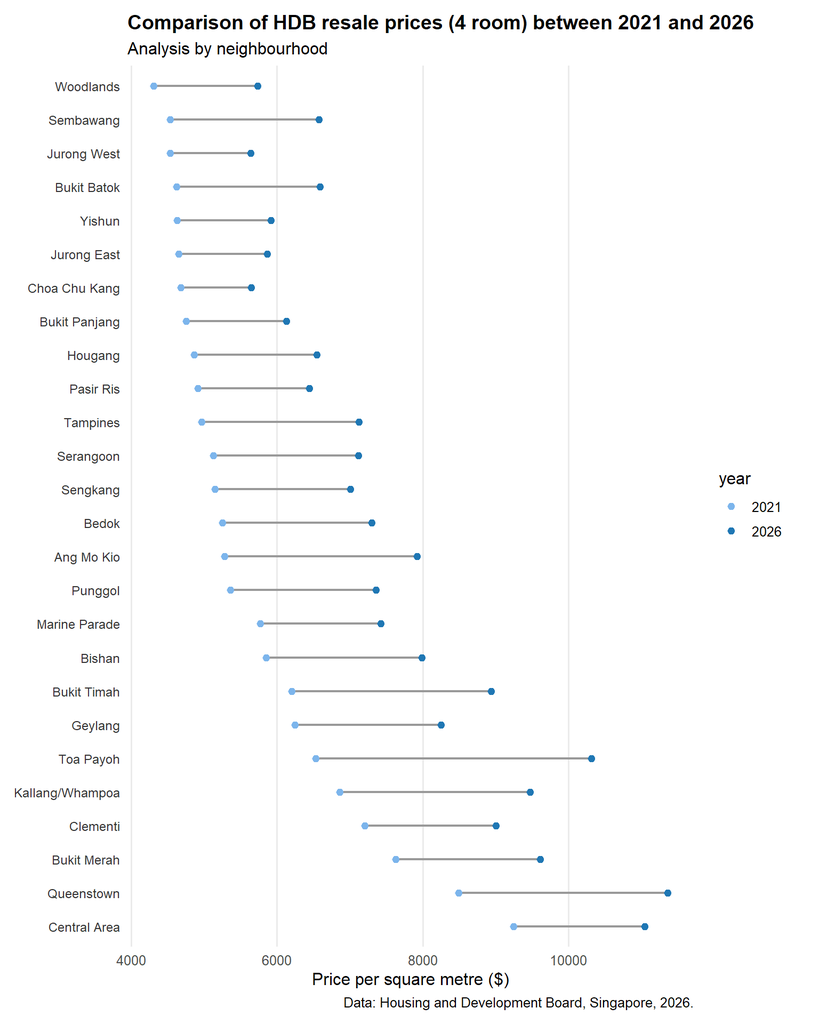

```r
ggplot(df_dumbbell) +
  geom_segment(
    aes(x = yr_2021, xend = yr_2026, y = town_label, yend = town_label),
    color = 'grey60',
    size = 0.8
    ) +
  geom_point(aes(x = yr_2021, y = town_label, color = '2021'), size = 2) +
  geom_point(aes(x = yr_2026, y = town_label, color = '2026'), size = 2) +
  scale_color_manual(name = 'year',
                     values = c('2021' = color_2021, '2026' = color_2026)) +
  theme_minimal(base_size = 12) +
  labs(
    title = paste0('Comparison of HDB resale prices (4 room) between ',
                   '2021 and ',
                   '2026'),
    subtitle = 'Analysis by neighbourhood',
    x = 'Price per square metre ($)',
    y = NULL,
    caption = 'Data: Housing and Development Board, Singapore, 2026.'
  ) +
  theme(
    plot.title = element_markdown(size = 14, face = 'bold'),
    panel.grid.major.y = element_blank(),
    panel.grid.minor = element_blank(),
    axis.text.y = element_text(color = "gray20", size = 9),
    plot.margin = margin(10, 20, 10, 10)
  )
```

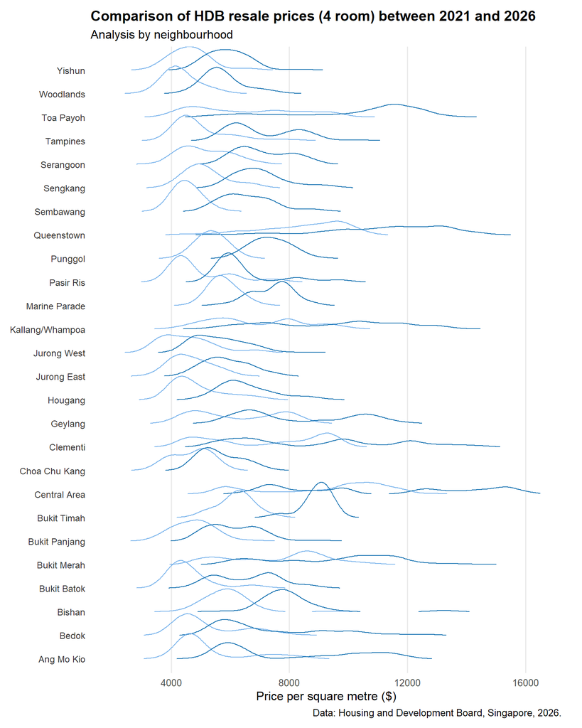

```r
ggplot(
  df_compare_base,
  aes(x = price_per_sqm, y = town_label, color = year_fct)
  ) +
  geom_density_ridges(
    fill = 'transparent',
    scale = 1.5,
    size = 0.6,
    rel_min_height = 0.005
  ) +
  scale_color_manual(values = c('2021' = color_2021, '2026' = color_2026)) +
  scale_x_continuous(breaks = c(4000, 8000, 12000, 16000), limits = c(2000, 16500)) +
  theme_minimal(base_size = 12) +
  labs(
    title = paste0('Comparison of HDB resale prices (4 room) between ',
                   '2021 and ',
                   '2026'),
    subtitle = 'Analysis by neighbourhood',
    x = 'Price per square metre ($)',
    y = NULL,
    caption = 'Data: Housing and Development Board, Singapore, 2026.'
  ) +
  theme(
    legend.position = 'none',
    plot.title = element_markdown(size = 14, face = 'bold'),
    panel.grid.major.y = element_blank(),
    panel.grid.minor = element_blank(),
    axis.text.y = element_text(color = "gray20", size = 9),
    plot.margin = margin(10, 20, 10, 10)
  )
```